# Cleaning Qualitative Data in R Guide

Hannah

March 17, 2025

Manager’s Summary

Data Cleaner’s Summary

## 0.1 Introduction

**Do not share this guide outside of OMNI**

Data cleaning is often one of the first things you will do when you start working with qualitative data at OMNI. Whether we’re working with interview transcripts, focus group discussions, or open-ended survey responses, the raw data we receive is rarely ready for immediate analysis. Cleaning is not just about tidying up; it’s about making informed decisions that clarify the meaning and integrity of the data while preparing it for systematic analysis.

The decisions we make during the cleaning process are every bit as complex and impactful as those made during coding and analysis. Thoughtful data cleaning can preserve the richness of qualitative data, while careless decisions can distort or diminish participants’ voices. Therefore, it is especially important to have a strong set of working principles to guide your decisions when cleaning qualitative data.

This guide covers a general approach to qualitative data cleaning, with an emphasis on useful R packages and functions designed to conquer some common challenges. While this guide includes tools and code to make your life easier, it also offers guidelines for making judgment calls about what to remove, retain, or clarify in the data.

The steps in a qualitative data cleaning process will always be informed by two key factors:

1. **The state of the data when we (OMNI) receive it**
- For example, some transcripts may come from automated services (like Zoom or Otter.ai) and contain timestamps, speaker labels, or filler words that require removal. Others may be professionally transcribed and need minimal cleaning.
2. **The specific needs of the project** Because of this variability, we encourage a flexible, judgment-driven approach to data cleaning. The steps described in this guide are common to many projects, but their order and application should be tailored to the needs of the dataset and the analytic goals of the project. Importantly, depending on the type of analysis, different cleaning steps may be required. Consult the analysis plan and research questions in your project materials to verify the needs of the project.

### 0.1.1 Supporting resources

## 0.2 Rationale

When we clean qualitative data, we apply a series of thoughtful transformations that make the data clearer, more consistent, and usable for analysis. Qualitative data cleaning requires attention to detail and sensitivity to the context in which the data were collected. The procedures we use need to be flexible because the downstream purposes of the data can vary from project to project—whether for thematic coding, content analysis, or mixed-methods integration.

The qualitative data cleaner often has to make many judgment calls during this process. These decisions are guided by the project’s goals, the nature of the source data, team experience, and guidance documents (like this one). Every decision and its rationale should be clearly documented in the data cleaning script or data log (more on that below). Transparency in this process ensures that the cleaned dataset remains trustworthy and aligned with our ethical standards for qualitative research.

Qualitative data cleaning requires a lot of careful thought and attention. The R code that cleans text data needs to be clearly written and well-commented, not only for reproducibility but to ensure that meaning is preserved, and participant voices are not inadvertently altered or diminished. In qualitative work, the cleaning process can directly impact the integrity of the analysis.

Just as with quantitative analysis, qualitative data-cleaning decisions are made with greater ease and clarity when there is a clear work plan, guided by the project’s research questions or evaluation goals. Having a shared understanding of what the team hopes to explore in the data helps inform:

In many cases, the people drafting the analysis plan are different from those cleaning the qualitative data, so strong cross-team communication is essential. We recommend including the qualitative data cleaner (or cleaning team) in project discussions as early as possible. When drafting the analysis plan, think through what text cleaning steps will be necessary to make the data usable for coding, protect participant confidentiality, and meet the project’s goals.

Finally, whether you’re writing code for qualitative data cleaning or any other purpose, always write your R scripts as if they will later be:

- Heavily scrutinized
- Held up as example code
- Modified by someone brand new to both R and the project

Make it easy on future OMNI-ites—and on your future self!

## 0.3 When are data clean?

✅ What Does It Mean to Have “Clean” Qualitative Data? For there to be project tasks that direct OMNI-ites to ‘clean qualitative data,’ and a guide to help in doing so, there should also be a shared understanding of what it means for qualitative data to be clean.

📝 Definition of Clean Qualitative Data: At OMNI, qualitative data are considered clean when they are organized, de-identified, and ready for analysis or coding.

That means the data:

Accurately reflect the original source material (e.g., interviews, focus groups, or open-text survey responses) Have been transformed into a structure that makes them easy to navigate and analyze Protect the privacy and confidentiality of participants Are consistent, clear, and free of irrelevant clutter (like transcription artifacts) 🎯 What Makes a Qualitative Dataset “Analysis-Ready”? For qualitative text data to be ready for analysis, they should meet the following criteria:

Speaker Information Is Clear and Consistent

Participant speakers and interviewers are clearly labeled in the data. Each speaker’s text is grouped logically into segments, preserving conversational flow. Participant Identifiers Are Specified and Protected

Real names, locations, and other direct identifiers have been removed or replaced with participant IDs or pseudonyms. Confidential information (e.g., agency names, job titles, organizations) is anonymized where necessary, following OMNI’s confidentiality guidelines. Questions Are Clearly Distinguished From Responses

Interviewer questions (or prompts) are labeled or separated from participant responses, as appropriate. This can be done by adding question text as its own field in the dataset or by adding markers in the transcript. Text Segments Are Ordered and Organized

The transcript text is ordered according to the flow of conversation. Segments are correctly time-sequenced (even if timestamps themselves are removed). Text Is Structured Into a Tidy, Rectangular Format

Each row represents a single speaker turn or unit of analysis (e.g., a complete response to a question). Data are stored in a rectangular table (data frame), with columns for: Session name or group (e.g., “Educators” or “Public Health”) Participant ID or role (e.g., “Participant 1,” “Facilitator”) Text segment (the response or comment) Any relevant metadata (e.g., discussion section, date) Timestamps and Transcription Artifacts Are Removed

All timestamps (e.g., [00:05:23], (0:12:45)) are deleted unless specifically required for analysis. Automated transcription quirks (e.g., repeated words, filler words, auto-captions like “[inaudible]”) are reviewed, cleaned, or flagged. Text Is Consistent in Style and Format

All text is converted to lowercase, unless case is important for analysis. Spelling errors are corrected when they obscure meaning (but regional spellings or participant quirks may be preserved if relevant). Punctuation and spacing are standardized (no excessive whitespace, missing periods, etc.). Relevant Identifiers Are Added to the Dataset

If there are multiple sessions or groups, these are labeled (e.g., “Educators,” “Public Health”). If there are themes or discussion sections (e.g., “Challenges,” “Recommendations”), these are identified. If codes are pre-assigned for analytic purposes (e.g., “Pre-implementation,” “Post-implementation”), they are included in the data structure. 💡 How Do We Know When Qualitative Data Are Clean? Here are some guiding questions to help determine when qualitative data are ready for analysis (i.e., clean):

What is the plan for coding or analyzing this data?

The analysis plan (or coding framework) should inform cleaning decisions. For example, if the team plans to do thematic coding, they’ll need text organized into meaningful speaker turns or responses. What needs to be anonymized?

Identify any sensitive information that must be redacted or replaced to maintain confidentiality and ensure participant privacy. Are speaker turns properly attributed and easy to follow?

Each speaker’s contributions should be clearly labeled, consistently formatted, and grouped logically. Are responses to specific questions clearly identifiable?

If interviews or focus groups follow a semi-structured guide, it’s important to separate questions from responses for clarity in analysis. Is the structure of the data appropriate for the analytic tool?

If the data are being uploaded to Dedoose, NVivo, or another platform, they should follow the required format (e.g., tidy data frame with speaker IDs and group names). Have all unnecessary artifacts been removed?

Time stamps, filler words, and transcription errors that don’t add value to the analysis should be removed. Has the cleaned data been reviewed by someone else (QA check)?

Whenever possible, have another OMNI-ite review the cleaned data for accuracy and completeness. ✨ Common Issues to Discuss Early in the Cleaning Process Just like in quantitative data cleaning, clarifying expectations at the start of a project will save time later. For qualitative projects, consider these:

Will we analyze both facilitator questions and participant responses, or just participant responses? How will we handle overlapping speech, interruptions, or incomplete thoughts? Do we need to standardize participant roles (e.g., “Public Health Official” vs. “PH Staff”) for consistency? Are we preparing data for manual coding or automated text analysis? Do we need to translate or transcribe non-English responses? Do we need to connect text segments with broader context, such as the discussion theme or section of the focus group? 🚀 In the Following Sections… We’ll see how these fundamentals—like tidy qualitative data, pipes, and regular expressions—play out in real-world cleaning tasks, such as:

Removing timestamps and filler words Labeling speakers and organizing segments Anonymizing sensitive information Structuring text for analysis software (Dedoose, NVivo, etc.) ✅ Quick Summary of “Clean Qualitative Data” at OMNI: Clean qualitative data are:

Anonymized Clearly structured and labeled Organized for easy analysis Free of unnecessary artifacts Ready for use in coding and interpretation

## 0.4 How do I report the results of data cleaning?

📝 How to Report the Results of Qualitative Data Cleaning at OMNI Cleaning qualitative data is an interpretive and decision-heavy process, and those decisions need to be transparent. Reporting your cleaning process helps:

Project leads understand what’s been done and why. Provide documentation in case changes need to be made later. Build trust in the integrity of the cleaned dataset. Support future qualitative coding, interpretation, and reporting. Qualitative data cleaning produces results—changes to the text or data structure—that should be documented in a clear, shareable data cleaning report.

📋 What to Include in a Qualitative Data Cleaning Report 1. Summary of the Dataset You Cleaned Start with an overview:

How many transcripts or files were cleaned? How many sessions (e.g., focus groups, interviews) are included? What types of participants are represented (e.g., educators, public health professionals)? Example: This dataset includes transcripts from 8 focus groups, with 42 participants. Participants represent two stakeholder groups: Educators (n = 20) and Public Health Professionals (n = 22).

2. Anonymization and De-Identification Steps Document what you removed or replaced to protect confidentiality.

Were participant names replaced with IDs (e.g., Participant 01)? Were organizations, locations, or personal identifiers removed or redacted? Were job titles generalized (e.g., “CEO” changed to “senior leader”)? Example: Replaced all participant names with Participant IDs (e.g., P01). Removed specific references to organizations and locations (e.g., “at Boulder Community Hospital” becomes “at [hospital]”). Redacted job titles for anonymity when mentioned alongside unique organizations.

3. Speaker Labeling and Text Structuring Describe how speakers were labeled and how the transcript was organized.

Were speakers consistently labeled as “Participant” and “Facilitator”? Was each speaker turn separated into its own row or segment? Were questions separated from responses? Example: Speaker turns were labeled consistently as either Facilitator or Participant. Each speaker turn is stored as one row in the cleaned dataset, with associated metadata (Session name, Speaker role, Discussion section).

4. Artifacts Removed (Timestamps, Filler Words, etc.) Note what transcription artifacts were removed or edited:

Were timestamps deleted? Were filler words (e.g., “um,” “uh”) removed? If so, specify whether this was systematic or case-by-case. Were transcription errors corrected? Example: Removed all timestamps in the format [hh:mm:ss]. Deleted common filler words (“um,” “uh”) unless they contributed to participant meaning or tone. Reviewed and corrected auto-transcription errors (e.g., “Dodoose” corrected to “Dedoose”).

5. Text Standardization and Formatting Summarize standardization steps for readability and consistency:

Was text converted to lowercase? Was spelling corrected? If so, did you preserve participant colloquialisms? Were consistent punctuation and spacing applied? Example: Converted all text to lowercase for consistency. Standardized punctuation (e.g., added periods to sentence ends where missing). Corrected spelling errors that obscured meaning but preserved participant vernacular and tone where appropriate.

6. Metadata or Contextual Information Added Note any metadata added to support analysis:

Session name (e.g., “Educators” vs. “Public Health Professionals”) Discussion section (e.g., “Challenges,” “Recommendations”) Participant role or group designation Example: Added metadata fields to identify Session Name, Participant Group (Educator/Public Health), and Discussion Section (Barriers, Facilitators, Recommendations).

7. Key Decisions Made During Cleaning Flag any important decisions that could impact analysis:

If you excluded any portions of text (e.g., off-topic discussions), document what was excluded and why. If you made choices about retaining or removing interruptions, overlapping speech, or non-verbal cues, describe the rationale. If you generalized identifying details in ways that may impact interpretation, note this. Example: Excluded introductory small talk (greetings, logistics discussions) from the analysis dataset. Retained overlapping speech where relevant to the discussion. Generalized certain job titles to preserve anonymity (e.g., “Head Nurse” changed to “Medical Staff”).

8. Counts and Summaries Where Relevant When helpful, include counts that summarize:

How many identifiers were removed? How many sessions, speakers, or responses are in the final dataset? If you organized by themes, how many segments are in each theme? Example: Final cleaned dataset includes 8 focus groups, 42 participants, and 620 participant responses across three discussion sections: Challenges (n = 220), Facilitators (n = 200), and Recommendations (n = 200).

💡 Tips for Reporting Qualitative Data Cleaning Be Transparent Even small decisions (e.g., standardizing speaker labels) can have big implications during analysis. If you’re unsure whether to document something, document it!

Take the Perspective of Your Project Lead or Analyst What decisions might they need to revisit later? What context would help them understand how the data were shaped?

Support Replicability and Quality Control Your cleaning report should make it easy for another team member to:

Understand what was done Re-run the cleaning script Suggest or request changes with full knowledge of the process 🖼️ Example Summary Table in a Qualitative Cleaning Report Cleaning Step Action Taken Notes Anonymization Removed names, replaced with Participant IDs (P01-P42) Locations and job titles generalized Speaker Labeling Labeled as Facilitator or Participant Consistent across all sessions Timestamps Removed Deleted all timestamps (hh:mm:ss)  
Filler Words Removed “um,” “uh” except when indicating hesitation Case-by-case review Text Standardization Converted to lowercase, corrected major spelling errors Preserved participant language/tone Metadata Added Session name, participant group, discussion section Useful for subgroup analysis Exclusions Removed introductions, off-topic discussions Documented in the data log

## 0.5 Terminology

📝 Relevant Terminology for Qualitative Data Cleaning in R 🔧 Data Structure & Format Terms Transcript A written or typed record of spoken language from interviews, focus groups, or meetings. Transcripts may include speaker labels, timestamps, and other artifacts that need cleaning.

Turn-Taking Each time a participant or facilitator speaks is called a “turn.” Clean data often organize these turns into individual rows in a dataset.

Segment (or Excerpt) A portion of text, such as a paragraph, sentence, or speaker turn, treated as a unit for coding or analysis. Segments are often defined by the speaker’s response or by topic.

Tidy Data Data where:

Each row represents a single observation (e.g., a speaker turn or segment) Each column contains one type of information (e.g., speaker ID, text, session group) Tidy data make it easier to manipulate, clean, and analyze qualitative datasets in R. Rectangular Data Another term for a table or data frame, where rows and columns are used to organize data in R.

🗂️ Qualitative Metadata & Labeling Terms Speaker Label An identifier showing who is speaking (e.g., “Facilitator,” “Participant 1”). Clean data should use consistent speaker labels.

Participant ID A unique identifier assigned to participants to protect anonymity (e.g., “P01”). These are often used in place of names.

Session ID / Group The label identifying the specific interview or focus group a participant was part of (e.g., “Session 1 – Educators”).

Discussion Section / Topic Area A label identifying a portion of the conversation (e.g., “Barriers,” “Recommendations”) to help organize qualitative data.

✂️ Data Cleaning & Transformation Terms Anonymization / De-Identification The process of removing or replacing personal identifiers (e.g., names, locations, job titles) to protect participant privacy.

Standardization Making text consistent in format (e.g., converting to lowercase, consistent punctuation, spacing).

Tokenization (Optional depending on your analysis!) Breaking down text into smaller parts—words, sentences, or phrases—typically for text mining. Not always part of standard qualitative coding workflows.

Filtering Removing unnecessary rows or segments (e.g., small talk, off-topic responses) from the data.

Recoding Transforming data from one format to another (e.g., generalizing job titles or grouping participant roles).

Join / Merge Combining two datasets based on a shared key (e.g., merging participant demographic info with transcripts).

Pivoting Restructuring data from wide format (many columns) to long format (many rows), or vice versa, to make it easier to analyze or display.

🏷️ Text Cleaning Terms Timestamps Time markers in transcripts (e.g., [00:12:34]) that need to be removed unless necessary for the analysis.

Filler Words Common speech disfluencies (e.g., “um,” “uh,” “like”) that can be removed for clarity, depending on analysis goals.

Inaudibles / Transcription Errors Markers like “[inaudible]” or machine transcription errors that need to be corrected or flagged.

Spelling and Grammar Standardization Correcting spelling errors that make text difficult to read, while preserving participant voice and tone where relevant.

# 1 Data cleaning procedures

The first step we’ll need to take is to figure out what kind of document you want to read into R.

## 1.1 Reading your data into R

First, we’ll need to read our data into R. Depending on how your raw text is stored, you’ll need to take various steps to read in your data for analysis. The goal is to turn any of your text into a dataframe with rows and columns of your text responses. In some cases, you may need to keep participant ID columns or other columns if you’re doing a mixed-method analysis. In other cases, you may be analyzing different focus groups and comparing them to eachother. Whatever you are doing, make sure your dataframe is set up or your analysis. If you are unsure about this, ask Hannah or a member of Qual BPT for some help!

Here is an example of what your data may look like when you first read it into R.

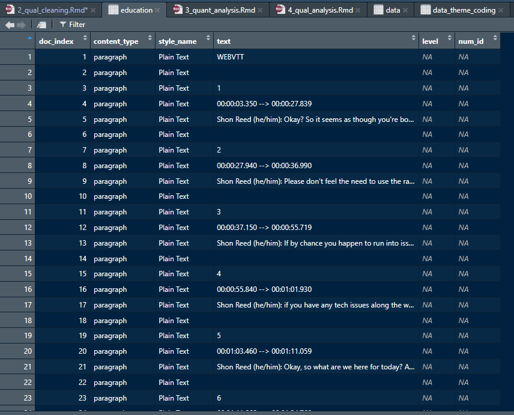

and here’s what we want it to look like (eventually) for most of our analysis needs.

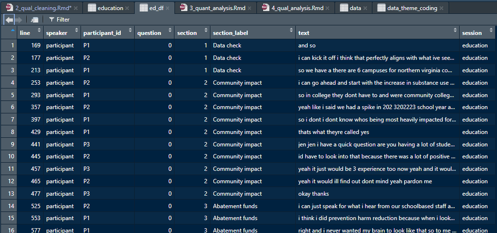

With clean data, we can:

- Compare participants’ responses across sessions and discussion sections. We could answer questions like:
  - What did Educators say about Community Impact vs. Public Health?”
  - What did participants across all interviews think about abatement funds?
- Filter by participant role (e.g., facilitators vs. participants) for targeted analysis. We could answer questions like:
  - How many participants mentioned that the county should invest in wraparound services across all interviews?
  - What is the most common barrier in accessing services in the county?
- Preserve anonymity by removing names and identifiers.

### 1.1.1 Zoom transcripts

This example comes from the Loudoun County Opioid Abatement project where Shon, Lindsay, Hannah, Luke, Eden, and Arden are staffed, so any of them could have been an interviewer.

In the case where an interviewer asks a question an exact way, we can enter the question as it is listed on the interview guide. However, this is not always the best way to run an interview when you’re following a more relaxed vibe. So, it may be helpful to have the interview guide (or deck, whatever the interviewer used to facilitate the discussion) and the transcript opened to identify the order of discussion and section labels, and to identify where those key markers of the text are going to identify your questions.

What is a good example of a question list if the interviewer did not read the question verbatim? Let’s imagine the first question listed on the interview guide is “What kinds of barriers do you think prevent community members from accessing services in the county?”.

Bad example: “accessing services” this is a bad example because this phrase has been marked as an identifier for a question, so any instance of “accessing services” comes up will count the phrase as a question.

Good example: “barriers do you think prevent community members from accessing services” it is less likely for someone to have used this exact string of words in the conversation, so we’re safe to mark this as a question identifier.